# Best books by century

Marian Nehrebecki, Aleksander Partyga, Magdalena Sobala

07 June, 2022

## **Century 20**

### Overview

(From the [Goodreads](https://www.goodreads.com)) Goodreads.com is the world’s largest site for readers and book recommendations. The mission of Goodreads is to help people find and share books they love.

The users can rate their favourite books, create lists and share their opinions with their friends. The website also provides extensive information on books from all genres and centuries; it also provides the users with rankings, available by different parameters. The rankings that are of interest to us, are the rating by the century. Below you can find a short summary of each century’s best books.

### A few things we can do on Goodreads

> - See what books our friends are reading.
> - Track the books we are reading, have read, and want to read.
> - Check out our personalized book recommendations. The recommendation engine analyzes 20 billion data points to give suggestions tailored to our literary tastes.
> - Find out if a book is a good fit for us from our community’s reviews.

# Summary of the Best books in Century 20

*Goodreads* provides its users with information on 7547 books from **Century 20** that have been published by Author/Authors from **Harper Lee** to **V.S. Naipaul**.

The best book in Century 20 was **To Kill a Mockingbird** by **Harper Lee** which gathered *9955 votes*, *983083 scores* and an average rating of *4.9*.

The book can be found under the following link: “https://www.goodreads.com/book/show/2657.To_Kill_a_Mockingbird”

## Visualisations:

### Books that were rated the most times in Century 20

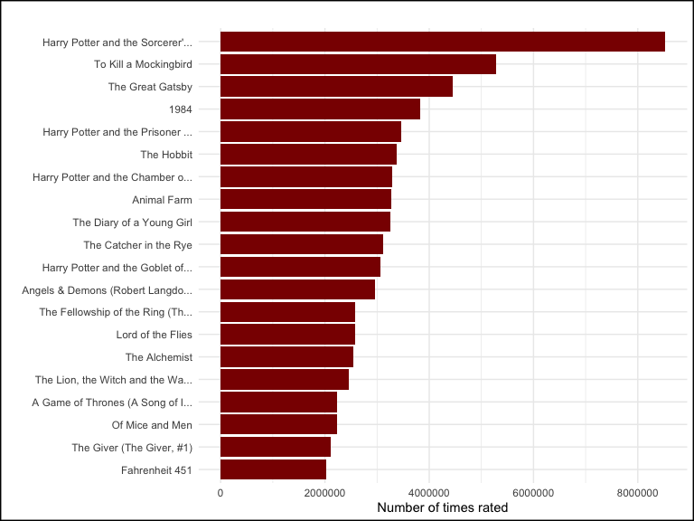

**Summary:**

- The book that was rated the most in Century 20 is **Harry Potter and the Sorcerer’s Stone (Harry Potter, #1)**, and the number of votes is **8525498**.
- The average number of voted for a book from Century 20 is equal **43565.5**.

### Books with the highest scores in Century 20

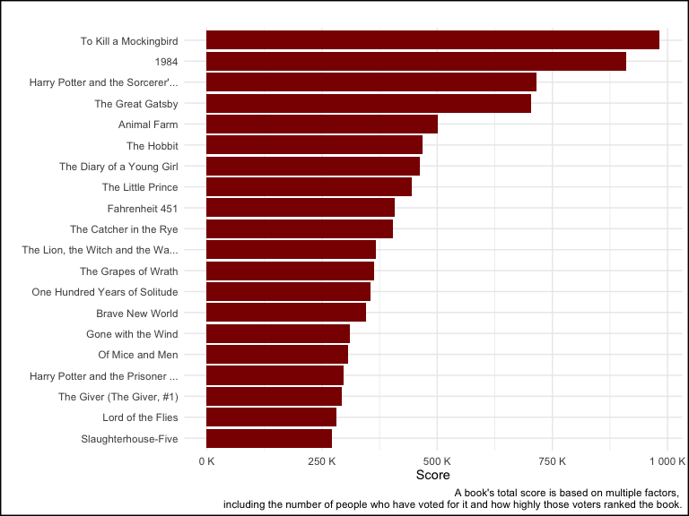

**Summary:**

- The maximum score for a book in Century 20 is **983083** for the book: **To Kill a Mockingbird**.
- The average score of all books in Century 20 is **3531.1**.
- The minimum score for a book in Century 20 is **1** for the book: **Everlastin’ (Everlastin’, #1), The Troika, The Case of Charles Dexter Ward, German Autumn, Secolul meu: confesiunile unui intelectual european, The Eight (The Eight #1), Collected Short Fiction**.

### Most prolific authors in Century 20

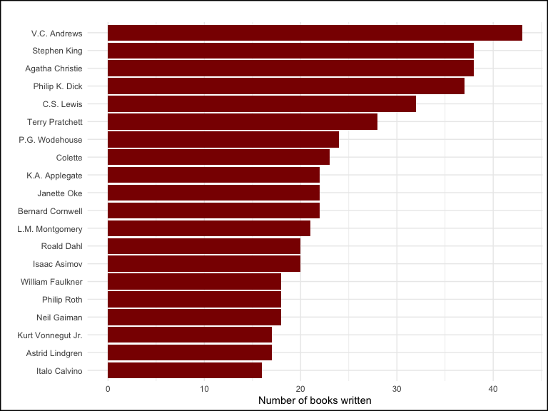

**Summary:**

- The most prolific author in Century 20 is **V.C. Andrews**.

## List of books with above average rating in Century 20

The number of books with the above average rating in Century 20 is **3956** out of all **7547** Century 20 books. The below table displays the top 10 results.

| Century | Title | Author | website |
| --- | --- | --- | --- |
| 20th | The Harry Potter Collection 1-4 (Harry Potter, #1-4) | J.K. Rowling | https://www.goodreads.com/book/show/99298.The_Harry_Potter_Collection_1_4 |
| 20th | The Boys from Brazil | Ira Levin | https://www.goodreads.com/book/show/99894.The_Boys_from_Brazil |
| 20th | El rey de hierro (Los Reyes Malditos, #1) | Maurice Druon | https://www.goodreads.com/book/show/99523.El_rey_de_hierro |
| 20th | How to Become King | Jan Terlouw | https://www.goodreads.com/book/show/995778.How_to_Become_King |
| 20th | The Secret Life of Plants: A Fascinating Account of the Physical, Emotional and Spiritual Relations Between Plants and Man | Peter Tompkins | https://www.goodreads.com/book/show/99442.The_Secret_Life_of_Plants |
| 20th | La loba de Francia (Los Reyes Malditos, #5) | Maurice Druon | https://www.goodreads.com/book/show/99499.La_loba_de_Francia |
| 20th | The Mystery of Tally-Ho Cottage (The Five Find-Outers, #12) | Enid Blyton | https://www.goodreads.com/book/show/994241.The_Mystery_of_Tally_Ho_Cottage |
| 20th | Beatles (Beatles-trilogien, #1) | Lars Saabye Christensen | https://www.goodreads.com/book/show/9970841-beatles |
| 20th | The Spirit of St. Louis (Borealis Book S.) | Charles A. Lindbergh | https://www.goodreads.com/book/show/995829.The_Spirit_of_St_Louis |
| 20th | La flor de lis y el león (Los Reyes Malditos, #6) | Maurice Druon | https://www.goodreads.com/book/show/99486.La_flor_de_lis_y_el_le_n |

### References:

https://www.goodreads.com